# PPOL 564: Data Science 1 - Foundations

## Factors Associated with Variation in Medicaid Application Processing Time Across States

### Caroline Adams

### Final Project Presentation

# Problem Statement

Individuals with low incomes and/or disabilities face multiple barriers to obtaining Medicaid coverage.

Eligibility criteria and determination processes vary widely by state program, leading to inequities in the ability and time it takes to enroll in Medicaid.

Delays in coverage provision can force eligible individuals to forgo or postpone neeeded care or lead to unnecessary financial burden.

# Background

Medicaid is a safety-net health insurance program.

- Jointly financed by states and the federal government
- Provides coverage for individuals with low incomes or disabilities

Medicaid eligibility and application processes vary by state.

State-level factors including wealth, infrastructure (technology and personnel), and political leaning are thought to influence eligibility processes

# Data Sources

1. Medicaid eligibility determination time observations by state and year (Centers for Medicare and Medicaid Services)
2. Medicaid expansion status by state (CMS, Kaiser Family Foundation)
3. Medicaid managed care status (KFF)
4. Total Medicaid enrollment numbers by state and year (CMS)
5. Ability of states to make real-time eligibility determinations (<24 hours) (KFF)
6. Political leaning by state (FiveThirtyEight)
7. State-level demographics (American Community Survey)

# Methods Used To Date

### Phase 1: Data wrangling and joining

- Downloaded CSV files for data on:

  ```
    - Medicaid expansion status
    - Medicaid managed care status
    - Medicaid enrollment (2018, 2019, 2020)
    - Real-time eligility determination ability
  ```

- Downloaded PDF files and converted to CSV for data on:

  ```
    - Medicaid eligibility determination time
        - 2018, 2019, 2020 data
  ```

- Scraped 538 website for data on:

  ```
    - Political leaning by state
  ```

- Set unit of analysis for all data to state
- Converted categorical information into dummy variables
- Joined data for respective year on State name

### Phase 2: Data visualization

- Visually assessed:
  - Medicaid enrollment numbers by state
  - Eligibility determination times at the national level
  - Eligibility determination times by determination technology status
  - Eligibility determination times by expansion status
  - Eligibility determination times by political leaning

# Additional Methods Considered & Next Steps

### Phase 1: Data wrangling and joining

- Download CSV files of American Community Survey data

  ```
    - State level demographics (e.g., race/ethnicity, income)
  ```

### Phase 2: Data visualization

- Visually assess changes in determination times by state over time
- Explore determination times by varying state level demographics
- Explore determination times by presence of Medicaid managed care

### Phase 3: Machine learning

- Develop models that are predictive of eligibility determination time
- Include factors such as:

  ```
    - Ability to make real-time eligibility determinations
    - Use of online application portals
    - Medicaid expansion status
    - State political leaning
    - Presence of Medicaid managed care
    - State level demographics
    - Number of Medicaid enrollees
  ```

- Account for temporal variation in outcome variable

# Preliminary Results

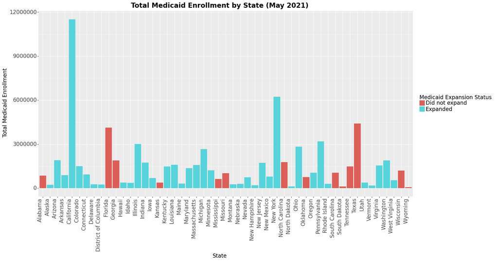

```python
MedEnrollbyState
```

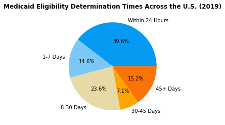

```python
plt.pie(nat_mean_19_t['National Total'], labels=['Within 24 Hours', "1-7 Days", "8-30 Days", "30-45 Days", "45+ Days"], colors=colors, autopct='%1.1f%%')
plt.title("Medicaid Eligibility Determination Times Across the U.S. (2019)", fontweight="bold")
plt.show()
```

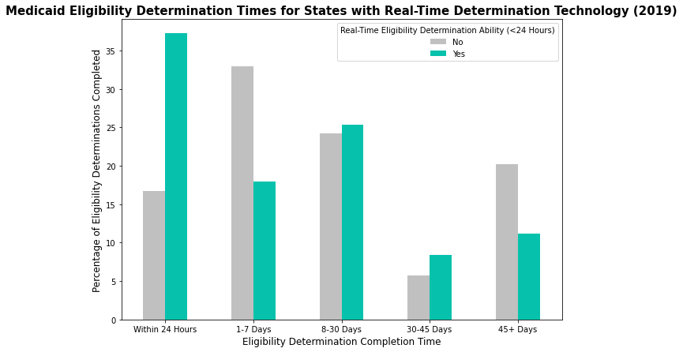

```python
grouped_19_rted.plot(kind="bar", stacked=False, figsize=(10,7), color=['#C0C0C0', "#06C2AC"])  #creating a stacked bar chart based on queried data
plt.title("Medicaid Eligibility Determination Times for States with Real-Time Determination Technology (2019)", fontsize=15, fontweight="bold")  #adding a plot title
plt.ylabel("Percentage of Eligibility Determinations Completed", fontsize=12)  #adding a y axis label
plt.xlabel("Eligibility Determination Completion Time", fontsize=12)  #adding an x axis label
ticks=np.arange(len(grouped_19_rted))
plt.yticks(fontsize=10)
plt.xticks(ticks=ticks, labels=["Within 24 Hours", "1-7 Days", "8-30 Days", "30-45 Days", "45+ Days"], fontsize=10, rotation=0)
plt.show()
```

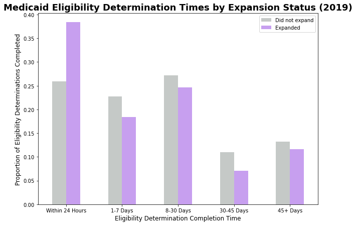

```python
grouped_19_exp.plot(kind="bar", stacked=False, figsize=(10,7), color=['#C5C9C7', "#C79FEF"])  #creating a stacked bar chart based on queried data
plt.title("Medicaid Eligibility Determination Times by Expansion Status (2019)", fontsize=18, fontweight="bold")  #adding a plot title
plt.ylabel("Proportion of Eligibility Determinations Completed", fontsize=12)  #adding a y axis label
plt.xlabel("Eligibility Determination Completion Time", fontsize=12)  #adding an x axis label
ticks=np.arange(len(grouped_19_exp))
plt.yticks(fontsize=10)
plt.xticks(ticks=ticks, labels=["Within 24 Hours", "1-7 Days", "8-30 Days", "30-45 Days", "45+ Days"], fontsize=10, rotation=0)
plt.legend(fontsize=10)
plt.show()
```

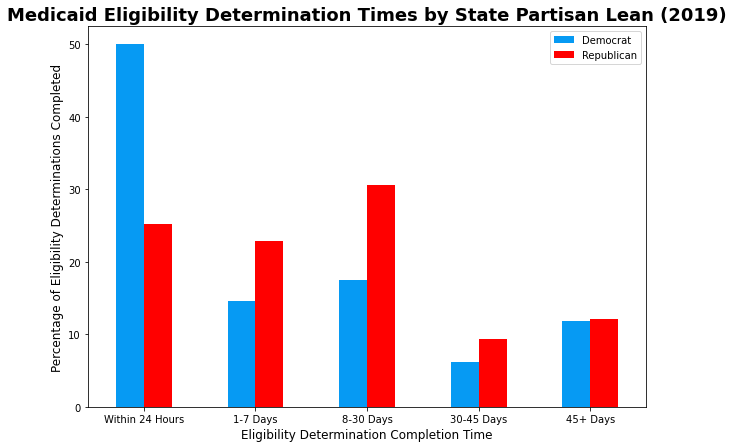

```python
grouped_19_partisan.plot(kind="bar", stacked=False, figsize=(10,7), color=['#069AF3', "#FF0000"])  #creating a stacked bar chart based on queried data
plt.title("Medicaid Eligibility Determination Times by State Partisan Lean (2019)", fontsize=18, fontweight="bold")  #adding a plot title
plt.ylabel("Percentage of Eligibility Determinations Completed", fontsize=12)  #adding a y axis label
plt.xlabel("Eligibility Determination Completion Time", fontsize=12)  #adding an x axis label
ticks=np.arange(len(grouped_19_partisan))
plt.yticks(fontsize=10)
plt.xticks(ticks=ticks, labels=["Within 24 Hours", "1-7 Days", "8-30 Days", "30-45 Days", "45+ Days"], fontsize=10, rotation=0)
plt.legend(fontsize=10)
plt.show()
```

# Preliminary Conclusions

### 1. Most eligibility determinations completed within a week across U.S. (>50%)

### 1. Wide state variation in eligiblity determination times

### 2. States with faster eligibility determination times:

```
- Utilize real-time eligibility determination technology (RTED)
- Expanded Medicaid
- Lean democrat
```

### 3. Not all states with RTED process all or most applications within 24 hours

# Lessons Learned

### Issues with application processing time data

```
- Low sample size
- Time series data
- Incomplete data collection by states
```

# Plans to Mitigate Challenges

### Challenge 1: Format of application processing time data

```
- Recode data to identify median processing time for each state (given month/year)
- Use median as outcome variable
```

### Challenge 1: Outcome variable is collected as time series data

```
- Explore if outcome varies across months/years
- Explore if outcome variable should be changed (change to difference across months/year)
- Utilize state and/or month/year dummy variables
- Potentially set next year's data as test data
```

### Challenge 2: Incomplete data (missingness)

```
- Limit sample to observations with all data components
```